# Research Update

Tyler Hoecker

12/17/2018

### General patterns

#### Details of calculations

We have looked at the general pattens already, but to review. Survival is calculated as the proportion of germinants that were still alive in October. “Establishment” is the product of survival and germination, or the count of living seedlings in October / the count of germinants. Proporitons are summarized three ways:

- “per site”: the mean of the proportions in each fire-aspect-frame that germinated/survived/established of all possible (50*5).
- “per aspect”: the mean of the proprotions in each aspect-frame.
- “per fire”: the mean of the proportions in each fire-framee.

Error bars in all cases are the 1 standard deviation of the same group from which the mean was calculated.

#### Key points

- Germination, survival and establishment is generally lower in south-facing aspect (17/24 cases), and higher in north-facing aspects (15/24 cases).
- Variation by site is different for germination, survival, establishment (e.g., average germination at Berry-Huck, but low survival).

### Question 1:

#### Are germination, survival and establishment significantly different among aspects and fire? How do PICO and PSME vary in their sensitivity to aspect and fire?

Historgams show distribution of data and effect of arc-sine square-root transformation. Data are still [true] zero-inflated.

Bar plots show proportions of each response by site, aspect and fire. Letter labels indicate means that are significantly different based on Tukey’s multiple comparisons.

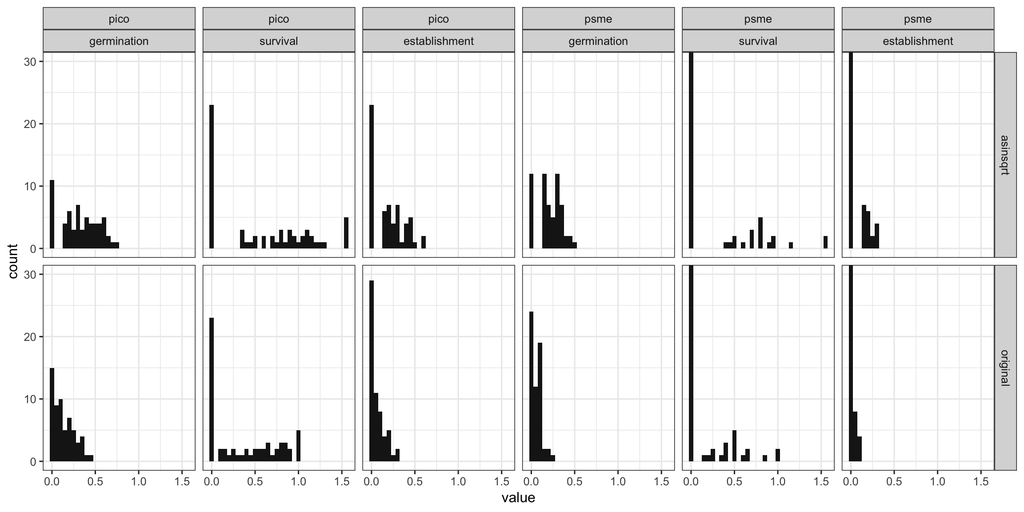

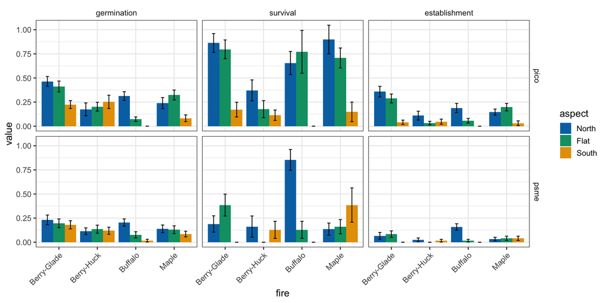

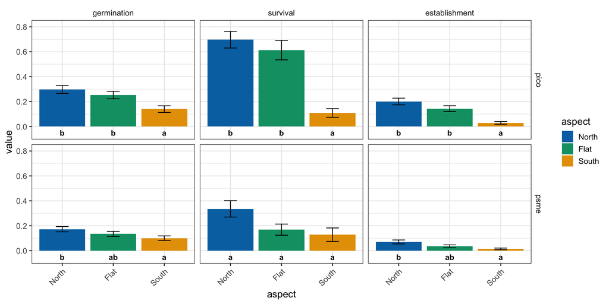

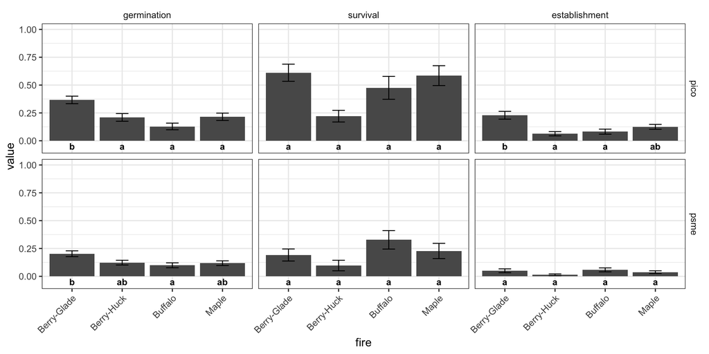

#### Approach: Two-way ANOVA of response ~ aspect + fire aspect:fire

PICO

| species | period | term | df | sumsq | meansq | statistic | p.value |
| --- | --- | --- | --- | --- | --- | --- | --- |
| pico | germination | aspect | 2 | 0.455 | 0.227 | 11.398 | 0.000 |
| pico | germination | fire | 3 | 0.730 | 0.243 | 12.194 | 0.000 |
| pico | germination | aspect:fire | 6 | 0.551 | 0.092 | 4.605 | 0.001 |
| pico | germination | Residuals | 48 | 0.957 | 0.020 | NA | NA |
| pico | survival | aspect | 2 | 5.671 | 2.835 | 16.377 | 0.000 |
| pico | survival | fire | 3 | 1.912 | 0.637 | 3.681 | 0.018 |
| pico | survival | aspect:fire | 6 | 1.270 | 0.212 | 1.222 | 0.312 |
| pico | survival | Residuals | 48 | 8.311 | 0.173 | NA | NA |
| pico | establishment | aspect | 2 | 0.627 | 0.314 | 27.756 | 0.000 |
| pico | establishment | fire | 3 | 0.446 | 0.149 | 13.160 | 0.000 |
| pico | establishment | aspect:fire | 6 | 0.286 | 0.048 | 4.213 | 0.002 |
| pico | establishment | Residuals | 48 | 0.542 | 0.011 | NA | NA |

PSME

| species | period | term | df | sumsq | meansq | statistic | p.value |
| --- | --- | --- | --- | --- | --- | --- | --- |
| psme | germination | aspect | 2 | 0.108 | 0.054 | 3.734 | 0.031 |
| psme | germination | fire | 3 | 0.189 | 0.063 | 4.359 | 0.009 |
| psme | germination | aspect:fire | 6 | 0.129 | 0.021 | 1.482 | 0.204 |
| psme | germination | Residuals | 48 | 0.694 | 0.014 | NA | NA |
| psme | survival | aspect | 2 | 0.731 | 0.366 | 2.905 | 0.064 |
| psme | survival | fire | 3 | 0.608 | 0.203 | 1.610 | 0.199 |
| psme | survival | aspect:fire | 6 | 3.246 | 0.541 | 4.297 | 0.002 |
| psme | survival | Residuals | 48 | 6.043 | 0.126 | NA | NA |
| psme | establishment | aspect | 2 | 0.081 | 0.040 | 5.783 | 0.006 |
| psme | establishment | fire | 3 | 0.042 | 0.014 | 2.003 | 0.126 |
| psme | establishment | aspect:fire | 6 | 0.164 | 0.027 | 3.913 | 0.003 |
| psme | establishment | Residuals | 48 | 0.336 | 0.007 | NA | NA |

#### Tukey’s multiple comparisons by aspect

Tukey’s multiple comparisons

| species | period | term | comparison | estimate | conf.low | conf.high | adj.p.value |
| --- | --- | --- | --- | --- | --- | --- | --- |
| pico | germination | aspect | Flat-North | -0.052 | -0.203 | 0.098 | 0.683 |
| pico | germination | aspect | South-North | -0.205 | -0.356 | -0.054 | 0.005 |
| pico | germination | aspect | South-Flat | -0.153 | -0.304 | -0.002 | 0.046 |
| pico | survival | aspect | Flat-North | -0.092 | -0.434 | 0.250 | 0.795 |
| pico | survival | aspect | South-North | -0.693 | -1.035 | -0.352 | 0.000 |
| pico | survival | aspect | South-Flat | -0.601 | -0.943 | -0.260 | 0.000 |
| pico | establishment | aspect | Flat-North | -0.077 | -0.190 | 0.037 | 0.246 |
| pico | establishment | aspect | South-North | -0.245 | -0.359 | -0.131 | 0.000 |
| pico | establishment | aspect | South-Flat | -0.168 | -0.282 | -0.054 | 0.002 |
| psme | germination | aspect | Flat-North | -0.055 | -0.156 | 0.047 | 0.404 |
| psme | germination | aspect | South-North | -0.104 | -0.205 | -0.002 | 0.043 |
| psme | germination | aspect | South-Flat | -0.049 | -0.151 | 0.052 | 0.476 |
| psme | survival | aspect | Flat-North | -0.203 | -0.520 | 0.115 | 0.282 |
| psme | survival | aspect | South-North | -0.256 | -0.574 | 0.061 | 0.135 |
| psme | survival | aspect | South-Flat | -0.054 | -0.371 | 0.263 | 0.912 |
| psme | establishment | aspect | Flat-North | -0.055 | -0.129 | 0.019 | 0.181 |
| psme | establishment | aspect | South-North | -0.089 | -0.163 | -0.015 | 0.015 |
| psme | establishment | aspect | South-Flat | -0.034 | -0.108 | 0.040 | 0.520 |

**Key points:**

- Biggest contrast is Buffalo and Berry-Glade.
- Less variation by site for PSME than for PICO.
- Much less variation by site than by aspect for both species.

Tukey’s multiple comparisons

| species | period | term | comparison | estimate | conf.low | conf.high | adj.p.value |
| --- | --- | --- | --- | --- | --- | --- | --- |
| pico | germination | fire | Berry-Huck-Berry-Glade | -0.196 | -0.377 | -0.015 | 0.029 |
| pico | germination | fire | Buffalo-Berry-Glade | -0.307 | -0.488 | -0.126 | 0.000 |
| pico | germination | fire | Maple-Berry-Glade | -0.186 | -0.367 | -0.005 | 0.042 |
| pico | germination | fire | Buffalo-Berry-Huck | -0.111 | -0.292 | 0.070 | 0.374 |
| pico | germination | fire | Maple-Berry-Huck | 0.010 | -0.171 | 0.192 | 0.999 |
| pico | germination | fire | Maple-Buffalo | 0.121 | -0.060 | 0.302 | 0.295 |
| pico | survival | fire | Berry-Huck-Berry-Glade | -0.449 | -0.954 | 0.055 | 0.097 |
| pico | survival | fire | Buffalo-Berry-Glade | -0.161 | -0.666 | 0.343 | 0.832 |
| pico | survival | fire | Maple-Berry-Glade | -0.025 | -0.529 | 0.480 | 0.999 |
| pico | survival | fire | Buffalo-Berry-Huck | 0.288 | -0.217 | 0.792 | 0.438 |
| pico | survival | fire | Maple-Berry-Huck | 0.424 | -0.080 | 0.929 | 0.129 |
| pico | survival | fire | Maple-Buffalo | 0.136 | -0.368 | 0.641 | 0.890 |
| pico | establishment | fire | Berry-Huck-Berry-Glade | -0.222 | -0.378 | -0.066 | 0.002 |
| pico | establishment | fire | Buffalo-Berry-Glade | -0.197 | -0.353 | -0.041 | 0.008 |
| pico | establishment | fire | Maple-Berry-Glade | -0.127 | -0.283 | 0.029 | 0.149 |
| pico | establishment | fire | Buffalo-Berry-Huck | 0.025 | -0.131 | 0.181 | 0.973 |
| pico | establishment | fire | Maple-Berry-Huck | 0.096 | -0.060 | 0.251 | 0.374 |
| pico | establishment | fire | Maple-Buffalo | 0.070 | -0.086 | 0.226 | 0.633 |
| psme | germination | fire | Berry-Huck-Berry-Glade | -0.110 | -0.234 | 0.015 | 0.104 |
| psme | germination | fire | Buffalo-Berry-Glade | -0.149 | -0.273 | -0.024 | 0.013 |
| psme | germination | fire | Maple-Berry-Glade | -0.117 | -0.241 | 0.008 | 0.075 |
| psme | germination | fire | Buffalo-Berry-Huck | -0.039 | -0.164 | 0.085 | 0.837 |
| psme | germination | fire | Maple-Berry-Huck | -0.007 | -0.132 | 0.118 | 0.999 |
| psme | germination | fire | Maple-Buffalo | 0.032 | -0.092 | 0.157 | 0.902 |
| psme | survival | fire | Berry-Huck-Berry-Glade | -0.123 | -0.532 | 0.286 | 0.857 |
| psme | survival | fire | Buffalo-Berry-Glade | 0.157 | -0.252 | 0.566 | 0.742 |
| psme | survival | fire | Maple-Berry-Glade | 0.053 | -0.356 | 0.462 | 0.986 |
| psme | survival | fire | Buffalo-Berry-Huck | 0.279 | -0.130 | 0.688 | 0.280 |
| psme | survival | fire | Maple-Berry-Huck | 0.176 | -0.233 | 0.585 | 0.667 |
| psme | survival | fire | Maple-Buffalo | -0.103 | -0.512 | 0.305 | 0.908 |
| psme | establishment | fire | Berry-Huck-Berry-Glade | -0.057 | -0.156 | 0.041 | 0.424 |
| psme | establishment | fire | Buffalo-Berry-Glade | 0.013 | -0.085 | 0.112 | 0.984 |
| psme | establishment | fire | Maple-Berry-Glade | -0.015 | -0.114 | 0.083 | 0.976 |
| psme | establishment | fire | Buffalo-Berry-Huck | 0.070 | -0.028 | 0.169 | 0.242 |
| psme | establishment | fire | Maple-Berry-Huck | 0.042 | -0.057 | 0.140 | 0.676 |
| psme | establishment | fire | Maple-Buffalo | -0.029 | -0.127 | 0.070 | 0.867 |

#### Approach: Generalized linear mixed-effects model

Started down this road… but a number of issues came up. I think a GLMM of counts as a function of environmental variation + fire (fixed) + frame (random) with a Poisson link function would be a good approach, but I need to read more to apply it appropriately. Refs: Martin et al. 2005 (zero-inflation), Welsh et al. 1996, Dobbie & Welsh 2001 (two-part Poisson model)

### Developing hypotheses and metrics for specific environmental variables

#### Soil moisture

Soil moisture is a predictor variable I hypothesize to be important for survival and establishment.

Key idea that came out of meeting with Kate is to develop a cumulative metric of soil moisture stress. Based on an assumption that soil moisture stress is additive/cumulative, versus a brief “shock” to the system (like a short spike in temperature might be).

One approach is to model a unit of time as a function of soil moisture, fit a curve, and integrate the area under the curve. Below is a working example. This is a log-log model, which is what I used for a model of hydraulic conductance as a function of soil moisture for class. It may not be the appropriate model, but I’m not sure how to determine the best model *a priori* (need to do more reading…).

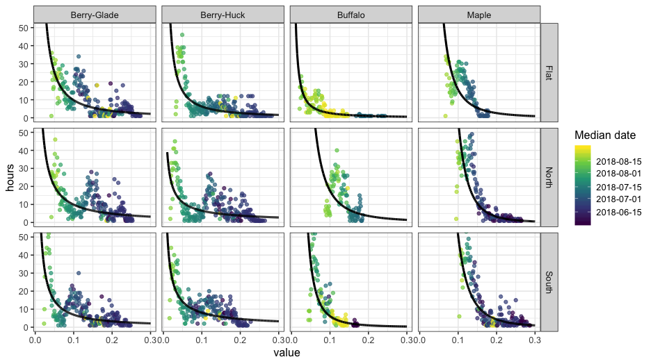

Further considerations:

- Current approach bins soil moisture into 0.001 classes by rounding, then counts the number of hours in each bin. It is ‘time agnostic’. Should it count the number of consecutive days below a threshold instead of total days in each bin?
- How to deal with missing data? E.g., if data were missing mid-summer, it could skew results toward higher moisture.
- Soil moisture seem to follow a bi-modal distribution, is there a way to account for this? E.g., a loess fit?
- How to decide what range of dates to use?